# Input data - results from MAGeCK

**Note:** if you use MAGeCKFlute in published research, please cite: Binbin Wang, Mei Wang, Wubing Zhang. “Integrative analysis of pooled CRISPR genetic screens using MAGeCKFlute.” Nature Protocols (2019), doi: [10.1038/s41596-018-0113-7](https://www.nature.com/articles/s41596-018-0113-7).

## Input data - results from MAGeCK

MAGeCK [@Wei2014] and MAGeCK-VISPR [@Wei2015] are developed by our lab previously, to analyze CRISPR/Cas9 screen data in different scenarios[@Tim2014, @Hiroko2014, @Ophir2014, @Luke2014, @Silvana2015]. Both algorithms use negative binomial models to model the variances of sgRNAs, and use Robust Rank Aggregation (for MAGeCK) or maximum likelihood framework (for MAGeCK-VISPR) for a robust identification of selected genes.

The command `mageck mle` computes beta scores and the associated statistics for all genes in multiple conditions. The **beta score** describes how the gene is selected: a positive beta score indicates a positive selection, and a negative beta score indicates a negative selection.

The command `mageck test` uses Robust Rank Aggregation (RRA) for robust identification of CRISPR-screen hits, and outputs the summary results at both sgRNA and gene level.

## Quick start

Here we show the most basic steps for integrative analysis pipeline. MAGeCKFlute package includes the MAGeCK results from one intrinsic dataset, including `countsummary`, `rra.gene_summary`, `rra.sgrna_summary`, and `mle.gene_summary`. We will work with them in this document.

```r
library(MAGeCKFlute)
library(ggplot2)
```

**Downstream analysis pipeline for MAGeCK RRA**

```r
##Load gene summary data in MAGeCK RRA results
data("rra.gene_summary")
data("rra.sgrna_summary")
##Run the downstream analysis pipeline for MAGeCK RRA
FluteRRA(rra.gene_summary, rra.sgrna_summary, proj="PLX", organism="hsa")
```

All pipeline results are written into local directory “./MAGeCKFlute_PLX/”, and all figures are integrated into file “PLX_Flute.rra_summary.pdf”.

**Downstream analysis pipeline for MAGeCK MLE** CRISPR screens can be conducted using three different cell populations: the day 0 population, a drug-treated population (treatment) and a control population (mockdrug control, typically treated with a vehicle such as DMSO). The CRISPR screens are required to analyze with MAGeCK MLE, which generates a gene summary file like `mle.gene_summary` below. FluteMLE is useful in this scenario to perform downstream analysis.

```r
data("mle.gene_summary")
## Run the downstream analysis pipeline for MAGeCK MLE
FluteMLE(mle.gene_summary, treatname="plx", ctrlname="dmso", proj="PLX", organism="hsa")
```

If CRISPR screens don't include a control cell population, FluteMLE supports users to use Depmap screens as control.

```r
## Take Depmap screen as control
FluteMLE(mle.gene_summary, treatname="plx", ctrlname="Depmap", proj="PLX", organism="hsa", incorporateDepmap = TRUE)
## If a specific cell line is preferred, you can look at the similarity of your screen with Depmap screens by using function ResembleDepmap.
depmap_similarity = ResembleDepmap(mle.gene_summary, symbol = "Gene", score = "plx.beta")
FluteMLE(mle.gene_summary, treatname="plx", ctrlname="Depmap", proj="PLX", organism="hsa", incorporateDepmap = TRUE, cell_lines = rownames(depmap_similarity)[1], lineages = "All")
```

All pipeline results are written into local directory “./MAGeCKFlute_PLX/”, and all figures are integrated into file “PLX_Flute.mle_summary.pdf”.

## Section I: Quality control

** Count summary ** `MAGeCK Count` in MAGeCK/MAGeCK-VISPR generates a count summary file, which summarizes some basic QC scores at raw count level, including map ratio, Gini index, and NegSelQC. Use function ‘data’ to load the dataset, and have a look at the file with a text editor to see how it is formatted.

```r
data("countsummary")
head(countsummary)
```

```
##                                   File    Label    Reads   Mapped
## 1 ../data/GSC_0131_Day23_Rep1.fastq.gz day23_r1 62818064 39992777
## 2  ../data/GSC_0131_Day0_Rep2.fastq.gz  day0_r2 47289074 31709075
## 3  ../data/GSC_0131_Day0_Rep1.fastq.gz  day0_r1 51190401 34729858
## 4 ../data/GSC_0131_Day23_Rep2.fastq.gz day23_r2 58686580 37836392
##   Percentage TotalsgRNAs Zerocounts GiniIndex NegSelQC NegSelQCPval
## 1     0.6366       64076         57   0.08510        0            1
## 2     0.6705       64076         17   0.07496        0            1
## 3     0.6784       64076         14   0.07335        0            1
## 4     0.6447       64076         51   0.08587        0            1
##   NegSelQCPvalPermutation NegSelQCPvalPermutationFDR NegSelQCGene
## 1                       1                          1            0
## 2                       1                          1            0
## 3                       1                          1            0
## 4                       1                          1            0
```

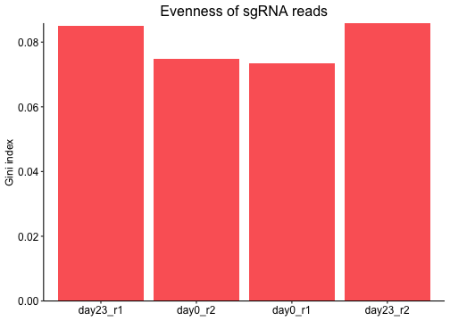

```r
# Gini index
BarView(countsummary, x = "Label", y = "GiniIndex",
        ylab = "Gini index", main = "Evenness of sgRNA reads")
```

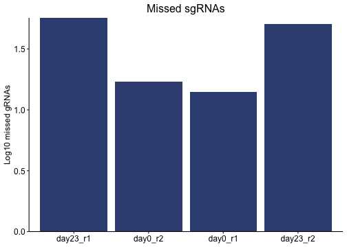

```r
# Missed sgRNAs
countsummary$Missed = log10(countsummary$Zerocounts)
BarView(countsummary, x = "Label", y = "Missed", fill = "#394E80",
        ylab = "Log10 missed gRNAs", main = "Missed sgRNAs")
```

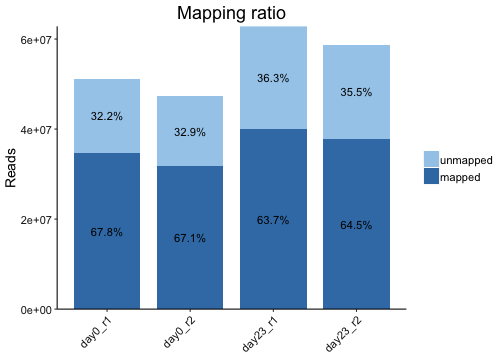

```r
# Read mapping
MapRatesView(countsummary)
```

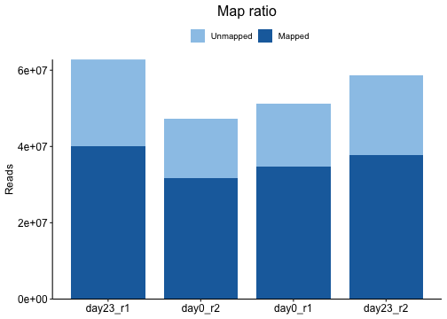

```r
# Or
countsummary$Unmapped = countsummary$Reads - countsummary$Mapped
gg = data.table::melt(countsummary[, c("Label", "Mapped", "Unmapped")], id.vars = "Label")
gg$variable = factor(gg$variable, levels = c("Unmapped", "Mapped"))
p = BarView(gg, x = "Label", y = "value", fill = "variable",
            position = "stack", xlab = NULL, ylab = "Reads", main = "Map ratio")
p + scale_fill_manual(values = c("#9BC7E9", "#1C6DAB"))
```

## Section II: Downstream analysis of MAGeCK RRA

For experiments with two experimental conditions, we recommend MAGeCK-RRA for identification of essential genes from CRISPR/Cas9 knockout screens. Gene summary file in MAGeCK-RRA results summarizes the statistical significance of positive selections and negative selections.

```r
library(MAGeCKFlute)
data("rra.gene_summary")
head(rra.gene_summary)
```

```
##       id num  neg.score neg.p.value  neg.fdr neg.rank neg.goodsgrna
## 1    NF2   4 4.1770e-12  2.9738e-07 0.000275        1             4
## 2 SRSF10   4 4.4530e-11  2.9738e-07 0.000275        2             4
## 3 EIF2B4   8 2.8994e-10  2.9738e-07 0.000275        3             8
## 4  LAS1L   6 1.4561e-09  2.9738e-07 0.000275        4             6
## 5   RPL3  15 2.3072e-09  2.9738e-07 0.000275        5            12
## 6 ATP6V0   7 3.8195e-09  2.9738e-07 0.000275        6             7
##   neg.lfc pos.score pos.p.value pos.fdr pos.rank pos.goodsgrna pos.lfc
## 1 -1.3580   1.00000     1.00000       1    16645             0 -1.3580
## 2 -1.8544   1.00000     1.00000       1    16647             0 -1.8544
## 3 -1.5325   1.00000     1.00000       1    16646             0 -1.5325
## 4 -2.2402   0.99999     0.99999       1    16570             0 -2.2402
## 5 -1.0663   0.95519     0.99205       1    15359             2 -1.0663
## 6 -1.6380   1.00000     1.00000       1    16644             0 -1.6380
```

### Visualization of negative selections and positive selections

#### Read the MAGeCK-RRA results

Two type of scores are optional, lfc (logrithm fold change) and rra (Robust Rank Aggregation score).

```r
dd.rra = ReadRRA(rra.gene_summary)
head(dd.rra)
```

```
##       id   Score      FDR
## 1    NF2 -1.3580 0.000275
## 2 SRSF10 -1.8544 0.000275
## 3 EIF2B4 -1.5325 0.000275
## 4  LAS1L -2.2402 0.000275
## 5   RPL3 -1.0663 0.000275
## 6 ATP6V0 -1.6380 0.000275
```

```r
dd.sgrna = ReadsgRRA(rra.sgrna_summary)
```

#### Compute the similarity between the CRISPR screen with Depmap screens

```r
depmap_similarity = ResembleDepmap(dd.rra, symbol = "id", score = "Score", lineages = "All", method = "pearson")
head(depmap_similarity)
```

```
##          estimate p.value
## A2780   0.5791483       0
## OVCAR8  0.5789564       0
## R262    0.5755967       0
## HS578T  0.5754257       0
## SF295   0.5751215       0
## KYSE180 0.5749847       0
```

#### Omit common essential genes from the data

```r
dd.rra = OmitCommonEssential(dd.rra)
dd.sgrna = OmitCommonEssential(dd.sgrna, symbol = "Gene")
# Compute the similarity with Depmap screens based on subset genes
depmap_similarity = ResembleDepmap(dd.rra, symbol = "id", score = "Score", lineages = "All", method = "pearson")
head(depmap_similarity)
```

```
##          estimate       p.value
## TE11    0.2394741 5.392597e-149
## OVCAR8  0.2390556 6.636024e-154
## YH13    0.2386189 2.470833e-153
## HUPT3   0.2380013 3.869874e-147
## NCIH661 0.2379885 1.640237e-152
## LXF289  0.2360406 5.494129e-150
```

#### Volcano plot

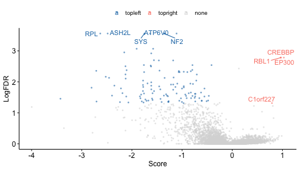

```r
dd.rra$LogFDR = -log10(dd.rra$FDR)
p1 = ScatterView(dd.rra, x = "Score", y = "LogFDR", label = "id", model = "volcano", top = 5)
print(p1)
```

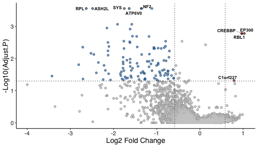

```r
# Or
p2 = VolcanoView(dd.rra, x = "Score", y = "FDR", Label = "id")
print(p2)
```

#### Rank plot

Rank all the genes based on their scores and label genes in the rank plot.

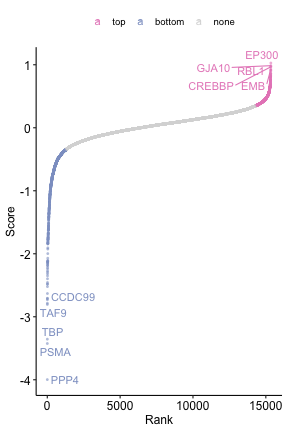

```r
dd.rra$Rank = rank(dd.rra$Score)
p1 = ScatterView(dd.rra, x = "Rank", y = "Score", label = "id",
                 top = 5, auto_cut_y = TRUE, groups = c("top", "bottom"))
print(p1)
```

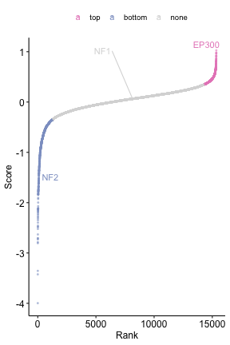

```r
# Label interested hits using parameter `toplabels` (in ScatterView) and `genelist` (in RankView).
ScatterView(dd.rra, x = "Rank", y = "Score", label = "id", auto_cut_y = TRUE,
            groups = c("top", "bottom"), toplabels = c("NF1", "EP300", "NF2"))
```

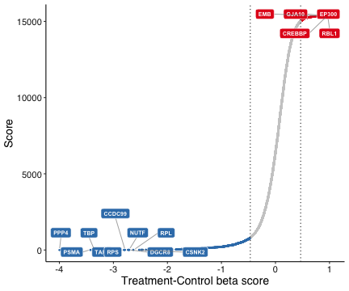

```r
# Or
geneList= dd.rra$Score
names(geneList) = dd.rra$id
p2 = RankView(geneList, top = 5, bottom = 10) + ylab("Score")
print(p2)
```

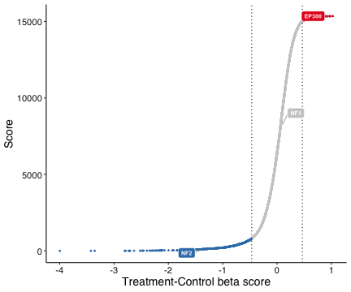

```r
RankView(geneList, top = 0, bottom = 0, genelist = c("NF1", "EP300", "NF2")) + ylab("Score")
```

#### Dot plot

Visualize negative and positive selected genes separately.

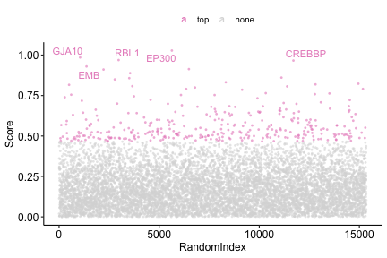

```r
dd.rra$RandomIndex = sample(1:nrow(dd.rra), nrow(dd.rra))
dd.rra = dd.rra[order(-dd.rra$Score), ]
p2 = ScatterView(dd.rra, x = "RandomIndex", y = "Score", label = "id",
                 y_cut = CutoffCalling(dd.rra$Score,2),
                 groups = "top", toplabels = dd.rra$id[1:5])
p2 + ylim(0, NA)
```

#### sgRankView - visualize the rank of sgRNAs targeting top selected genes.

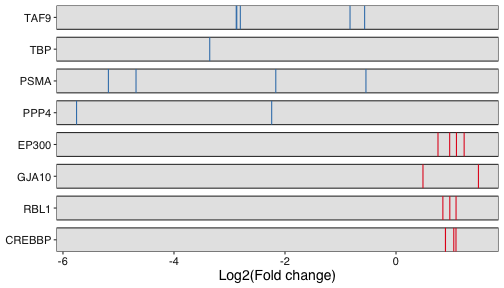

```r
p2 = sgRankView(dd.sgrna, top = 4, bottom = 4)
print(p2)
```

#### Enrichment analysis

For more information about functional enrichment analysis in MAGeCKFlute, please read the [MAGeCKFlute_enrichment document](https://www.bioconductor.org/packages/3.9/bioc/vignettes/MAGeCKFlute/inst/doc/MAGeCKFlute_enrichment.html), in which we introduce all the available options and methods.

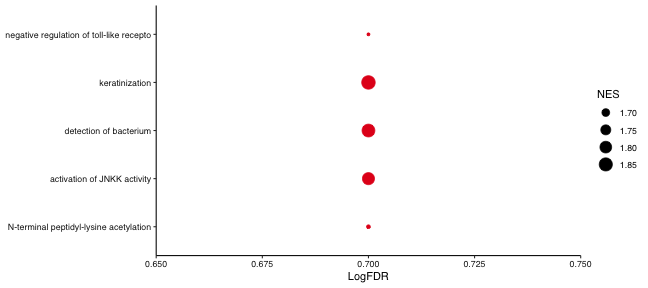

```r
geneList= dd.rra$Score
names(geneList) = dd.rra$id
enrich = EnrichAnalyzer(geneList = geneList, method = "GSEA", type = "GOBP")
EnrichedView(enrich)
```

## Section III: Downstream analysis of MAGeCK MLE

** Gene summary ** The gene summary file in MAGeCK-MLE results includes beta scores of all genes in multiple condition samples.

```r
data("mle.gene_summary")
dd=ReadBeta(mle.gene_summary)
head(dd)
```

```
##     Gene      dmso       plx
## 1   FEZ1 -0.045088 -0.036721
## 2    TNN  0.094325  0.065533
## 3  NAT8L  0.026362  0.044979
## 4   OAS2 -0.271210 -0.289010
## 5 OR10H3 -0.098324 -0.365730
## 6  CCL16 -0.309750 -0.148830
```

### Batch effect removal (not recommended)

Is there batch effects? This is a commonly asked question before perform later analysis. In our package, we provide `HeatmapView` to ensure whether the batch effect exists in data and use `BatchRemove` to remove easily if same batch samples cluster together.

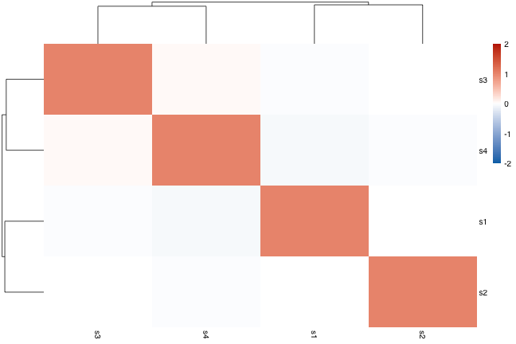

```r
##Before batch removal
edata = matrix(c(rnorm(2000, 5), rnorm(2000, 8)), 1000)
colnames(edata) = paste0("s", 1:4)
HeatmapView(cor(edata))
```

```r
## After batch removal
batchMat = data.frame(sample = colnames(edata), batch = rep(1:2, each = 2))
edata1 = BatchRemove(edata, batchMat)
```

```
## Standardizing Data across genes
```

```r
head(edata1$data)
```

```
##            s1       s2       s3       s4
## [1,] 6.254171 7.445805 6.238674 7.329760
## [2,] 6.349257 6.730243 5.831579 7.087445
## [3,] 7.323842 6.500166 6.343736 7.290178
## [4,] 5.966401 6.942698 6.865821 5.932180
## [5,] 8.135248 7.014937 8.567388 6.110857
## [6,] 7.243017 7.071499 7.516989 6.633036
```

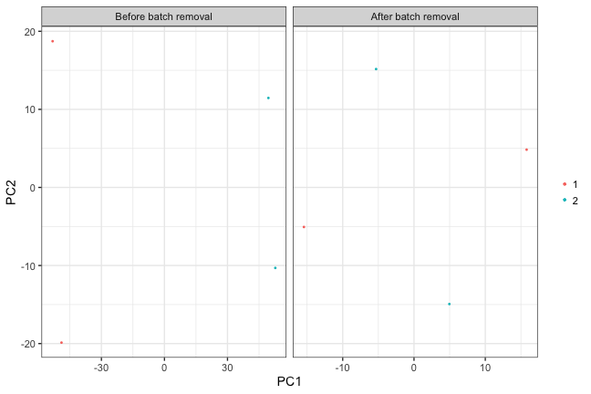

```r
print(edata1$p)
```

### Normalization of beta scores

It is difficult to control all samples with a consistent cell cycle in a CRISPR screen experiment with multi conditions. Besides, beta score among different states with an inconsistent cell cycle is incomparable. So it is necessary to do the normalization when comparing the beta scores in different conditions. Essential genes are those genes that are indispensable for its survival. The effect generated by knocking out these genes in different cell types is consistent. Based on this, we developed the cell cycle normalization method to shorten the gap of the cell cycle in different conditions. Besides, a previous normalization method called loess normalization is available in this package.[@Laurent2004]

```r
ctrlname = "dmso"
treatname = "plx"
dd_essential = NormalizeBeta(dd, samples=c(ctrlname, treatname), method="cell_cycle")
head(dd_essential)
```

```
##     Gene        dmso         plx
## 1   FEZ1 -0.05869343 -0.05660750
## 2    TNN  0.12278783  0.10102282
## 3  NAT8L  0.03431681  0.06933767
## 4   OAS2 -0.35304838 -0.44552525
## 5 OR10H3 -0.12799354 -0.56379346
## 6  CCL16 -0.40321793 -0.22942986
```

```r
#OR
dd_loess = NormalizeBeta(dd, samples=c(ctrlname, treatname), method="loess")
head(dd_loess)
```

```
##     Gene        dmso         plx
## 1   FEZ1 -0.04284757 -0.03896143
## 2    TNN  0.10223748  0.05762052
## 3  NAT8L  0.03207151  0.03926949
## 4   OAS2 -0.27195428 -0.28826572
## 5 OR10H3 -0.09901566 -0.36503834
## 6  CCL16 -0.31042984 -0.14815016
```

#### Distribution of all gene beta scores

After normalization, the distribution of beta scores in different conditions should be similar. We can evaluate the distribution of beta scores using the function ‘DensityView’, and ‘ConsistencyView’.

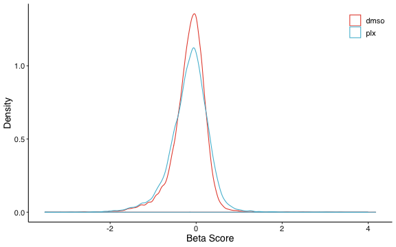

```r
DensityView(dd_essential, samples=c(ctrlname, treatname))
```

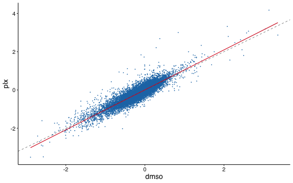

```r
ConsistencyView(dd_essential, ctrlname, treatname)
```

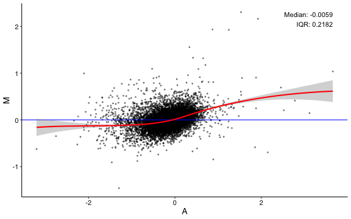

```r
# Another option MAView
MAView(dd_essential, ctrlname, treatname)
```

### Positive selection and negative selection

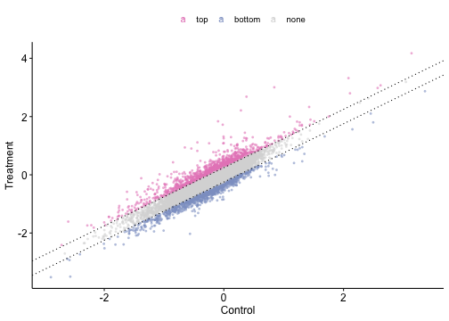

```r
dd_essential$Control = rowMeans(dd_essential[,ctrlname, drop = FALSE])
dd_essential$Treatment = rowMeans(dd_essential[,treatname, drop = FALSE])

p1 = ScatterView(dd_essential, "Control", "Treatment", groups = c("top", "bottom"), auto_cut_diag = TRUE, display_cut = TRUE, toplabels = c("NF1", "NF2", "EP300"))
print(p1)
```

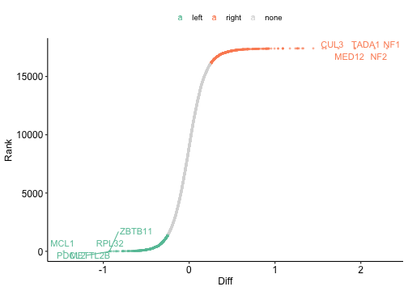

```r
dd_essential$Diff = dd_essential$Treatment - dd_essential$Control
dd_essential$Rank = rank(dd_essential$Diff)
p1 = ScatterView(dd_essential, x = "Diff", y = "Rank", label = "Gene",
                 top = 5, model = "rank")
print(p1)
```

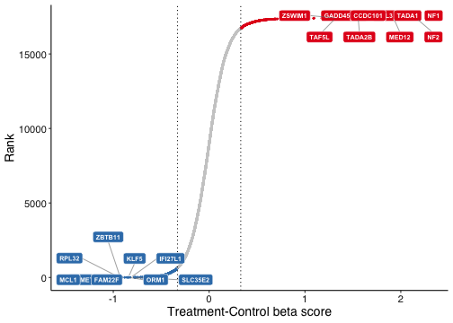

```r
# Or
rankdata = dd_essential$Treatment - dd_essential$Control
names(rankdata) = dd_essential$Gene
RankView(rankdata)
```

### Nine-square scatter plot - identify treatment-associated genes

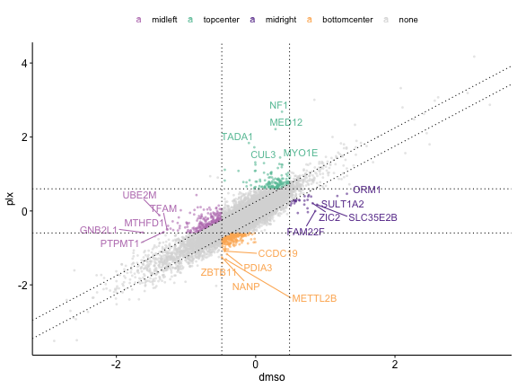

```r
p1 = ScatterView(dd_essential, x = "dmso", y = "plx", label = "Gene",
                 model = "ninesquare", top = 5, display_cut = TRUE, force = 2)
print(p1)
```

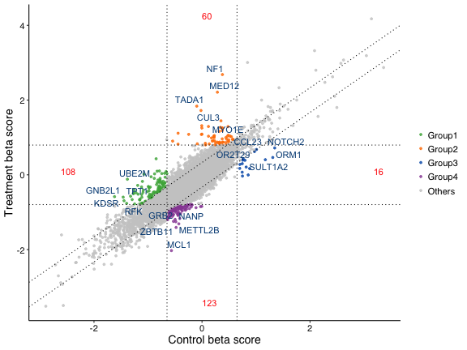

```r
# Or
p2 = SquareView(dd_essential, label = "Gene",
                x_cutoff = CutoffCalling(dd_essential$Control, 2),
                y_cutoff = CutoffCalling(dd_essential$Treatment, 2))
print(p2)
```

### Functional analysis for treatment-associated genes

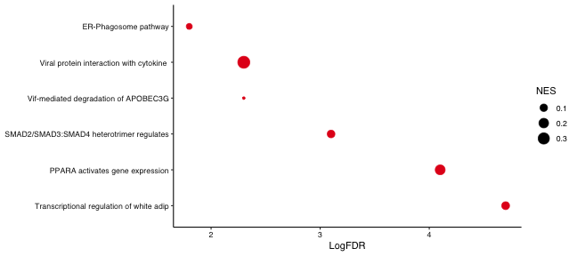

```r
# 9-square groups
Square9 = p1$data
idx=Square9$group=="topcenter"
geneList = Square9$Diff
names(geneList) = Square9$Gene[idx]
universe = Square9$Gene

# Enrichment analysis
kegg1 = EnrichAnalyzer(geneList = geneList, universe = universe)
EnrichedView(kegg1, top = 6, bottom = 0)
```

```r
genedata = dd_essential[, c("Control","Treatment")]
arrangePathview(genedata, pathways = "hsa01521", organism = "hsa", sub = NULL)
```

[output not shown]